# ЗАЩИТА ВЫПУСКНОЙ КВАЛИФИКАЦИОННОЙ РАБОТЫ

### Планирование реакции государственных органов и спасательных служб при разрушении слоя вечной мерзлоты в населённых пунктах

| Автор: | **Чубарова Дарья Алексеевна** |
| --- | --- |
| Научный руководитель: | **д.т.н., проф. Алескеров Фуад Тагиевич** |
| Программа: | «Исследование и предпринимательство в сфере ИИ» |
| Год: | 2026 |

НИУ «Высшая школа экономики», Москва

## Содержание презентации

| № | Раздел | Время |
| --- | --- | --- |
| 1 | Постановка проблемы и актуальность | 3 мин |
| 2 | Информационная база и обоснование границ | 5 мин |
| 3 | Описательная статистика климата | 4 мин |
| 4 | Метод LC-кривых: математика и интерпретация | 7 мин |
| 5 | **Интегральный индикатор PSRS — интерактивная модель** | 8 мин |
| 6 | Эмпирическая верификация PSRS | 5 мин |
| 7 | Регламент действий РСЧС и кейс Норильск-2020 | 3 мин |
| 8 | Заключение, научная новизна, практический выход | 5 мин |
|  | **Итого** | **≈ 40 мин** |

```python
# --- Установка и импорт зависимостей (выполнить один раз) ---
import os, sys, csv, math, warnings
warnings.filterwarnings('ignore')
import numpy as np
import pandas as pd
import matplotlib.pyplot as plt
from matplotlib.patches import Rectangle
import matplotlib as mpl

# Интерактив
try:
    import ipywidgets as widgets
    from IPython.display import display, HTML, Markdown
    INTERACTIVE = True
except ImportError:
    INTERACTIVE = False
    print("ipywidgets не установлен — интерактив отключён, графики работают")

# Базовая стилистика для графиков
plt.rcParams.update({
    'font.family': 'DejaVu Sans',
    'font.size': 12,
    'axes.titlesize': 14,
    'axes.labelsize': 12,
    'axes.grid': True,
    'grid.alpha': 0.3,
    'figure.dpi': 110,
    'figure.figsize': (11, 5.5),
    'axes.spines.top': False,
    'axes.spines.right': False,
})

# Путь к репозиторию
REPO = os.path.dirname(os.path.abspath(os.getcwd()))
# Если запускаем из Diploma/, то репозиторий — на уровень выше
if os.path.basename(os.getcwd()) == 'Diploma':
    REPO = os.path.dirname(os.getcwd())
else:
    REPO = os.getcwd()
print(f"[OK] Репозиторий: {REPO}")
print(f"[OK] Python {sys.version.split()[0]}")
```

```
[OK] Репозиторий: /sessions/affectionate-nifty-brown/mnt/permafrost_analysis-main
[OK] Python 3.10.12
```

# 1. Постановка проблемы

## Цепочка риска

| Климатическая аномалия | → | Деградация ММГ | → | Просадка оснований | → | Чрезвычайная ситуация |
| --- | --- | --- | --- | --- | --- | --- |

## Объект исследования

**Якутск** — крупнейший населённый пункт в зоне сплошной криолитозоны.

- Среднегодовая температура грунта на глубине 3,2 м под городской застройкой изменилась с **−1,02 °C** (1970-е гг.) до **+0,15 °C** (2023 г.).
- Линейный тренд потепления: **+0,221 °C/десятилетие**.
- Прогноз пересечения нулевой среднегодовой изотермы: **2030–2032 гг.**
- Один из крупнейших инженерных прецедентов в криолитозоне РФ — **разрушение резервуара ТЭЦ-3 в Норильске 29 мая 2020 г.** (разлив ~21 тыс. т дизельного топлива из-за просадки свайного основания).

## Главная задача работы

Создать **методический и программный инструмент**, который переводит данные мерзлотного и климатического мониторинга в **конкретные управленческие действия** оперативного штаба РСЧС / МЧС России.

# 2. Информационная база

## Четыре блока данных, каждый из верифицированного источника

| Блок | Параметры | Источник | Период |
| --- | --- | --- | --- |
| Климат | T воздуха, осадки, снег | ВНИИГМИ-МЦД, портал meteo.ru | 2008–2023 |
| Гидрология | Уровни воды, пики половодий | AllRivers (Дальневосточное УГМС, Центр регистра) | 2008–2023 |
| Геокриология (ALT) | Сезонно-талый слой | Программа CALM (площадки R42, R43) | 2008–2023 |
| Геокриология (T_грунта) | Температура на 320 см | ВНИИГМИ-МЦД (АИСОРИ-М), форма wr373144a3 | 1970–2023 |
| Архив ЧС | События 1991–2024 | ГУ МЧС России по Респ. Саха (Якутия) | 1991–2024 |

## Опорная сеть: продольный профиль р. Лены

- **Метеостанции (4):** Киренск (верховья) → Олёкминск → **Якутск (целевой створ)** → Жиганск (низовья)
- **Гидропосты (5):** Ленск → Олёкминск → Покровск → **Якутск** → Жиганск
- **Площадки CALM (2):** R42 «Туймаада» (городская), R43 «Нелегер» (фоновая)

## Расчётный период: 2008–2023 гг.

Лимитирующий фактор — непрерывный ряд CALM. Все остальные более длинные ряды усечены до этого окна для жёсткой синхронизации.

```python
# --- Загрузка ключевого датасета: PSRS-компоненты по Якутску (готовый файл) ---
df_psrs = pd.read_csv(os.path.join(REPO, 'Diploma', 'psrs_empirical_model_results.csv'))
print(f"[OK] Загружено {len(df_psrs)} годовых наблюдений по Якутску (2008–2023)")
df_psrs[['year','ALT','T320','Hsnow','ROS','chs_count']].head(16)
```

```
[OK] Загружено 16 годовых наблюдений по Якутску (2008–2023)
```

|  | year | ALT | T320 | Hsnow | ROS | chs_count |
| --- | --- | --- | --- | --- | --- | --- |
| 0 | 2008 | 203.0 | -0.108834 | 31 | 0 | 4 |
| 1 | 2009 | 199.0 | -0.593776 | 23 | 0 | 1 |
| 2 | 2010 | 197.0 | -0.635989 | 20 | 0 | 1 |
| 3 | 2011 | 201.0 | -0.497808 | 33 | 0 | 2 |
| 4 | 2012 | 201.0 | -0.142623 | 36 | 0 | 5 |
| 5 | 2013 | 201.0 | -0.224932 | 32 | 0 | 6 |
| 6 | 2014 | 203.0 | 0.212877 | 36 | 1 | 3 |
| 7 | 2015 | 201.0 | -0.008493 | 27 | 0 | 1 |
| 8 | 2016 | 201.0 | 0.128962 | 33 | 0 | 0 |
| 9 | 2017 | 203.0 | 0.066027 | 32 | 0 | 1 |
| 10 | 2018 | 201.0 | -0.036337 | 27 | 0 | 8 |
| 11 | 2019 | 205.0 | -0.287791 | 37 | 0 | 0 |
| 12 | 2020 | 206.0 | 1.918571 | 46 | 0 | 2 |
| 13 | 2021 | 208.0 | 0.387387 | 34 | 0 | 1 |
| 14 | 2022 | 208.0 | 0.144101 | 33 | 0 | 2 |
| 15 | 2023 | 206.0 | 0.151940 | 46 | 1 | 3 |

# 3. Описательная статистика климата

Четыре опорные метеостанции, март–май 2008–2023 гг. Главные результаты:

- Наибольшие осадки — в **Киренске** и **Олёкминске**.
- Наименьшие осадки и снег — в **Якутске** (резко-континентальный аридный режим).
- Наибольший снежный покров — в **Жиганске** и **Киренске**.
- В Якутске чётко выделяются два года: **2014 г.** (аномально тёплая весна) и **2021 г.** (аномально холодная).

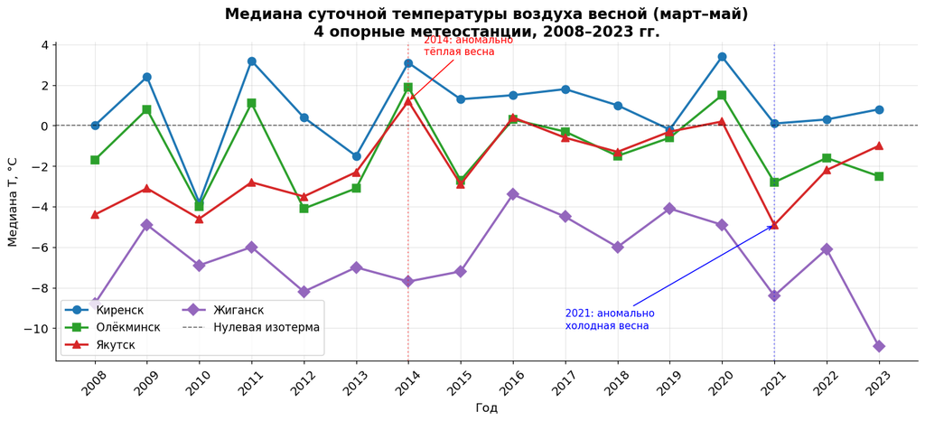

```python
# --- График: медиана весенней температуры по 4 станциям ---
years = list(range(2008, 2024))
t_kir  = [ 0.0, 2.4, -3.8, 3.2, 0.4, -1.5, 3.1, 1.3, 1.5, 1.8, 1.0, -0.2, 3.4, 0.1, 0.3, 0.8]
t_olek = [-1.7, 0.8, -4.0, 1.1, -4.1, -3.1, 1.9, -2.7, 0.3, -0.3, -1.5, -0.6, 1.5, -2.8, -1.6, -2.5]
t_yak  = [-4.4, -3.1, -4.6, -2.8, -3.5, -2.3, 1.2, -2.9, 0.4, -0.6, -1.3, -0.3, 0.2, -4.9, -2.2, -1.0]
t_zhg  = [-8.8, -4.9, -6.9, -6.0, -8.2, -7.0, -7.7, -7.2, -3.4, -4.5, -6.0, -4.1, -4.9, -8.4, -6.1, -10.9]

fig, ax = plt.subplots(figsize=(13, 6))
for name, vals, col, mk in [('Киренск', t_kir, '#1f77b4', 'o'),
                             ('Олёкминск', t_olek, '#2ca02c', 's'),
                             ('Якутск', t_yak, '#d62728', '^'),
                             ('Жиганск', t_zhg, '#9467bd', 'D')]:
    ax.plot(years, vals, color=col, marker=mk, linewidth=2.2, markersize=8, label=name)
ax.axhline(0, color='black', linestyle='--', linewidth=1, alpha=0.6, label='Нулевая изотерма')
ax.set_title('Медиана суточной температуры воздуха весной (март–май)\n4 опорные метеостанции, 2008–2023 гг.',
             fontsize=15, fontweight='bold')
ax.set_xlabel('Год'); ax.set_ylabel('Медиана T, °C')
ax.set_xticks(years); ax.tick_params(axis='x', rotation=45)
ax.legend(loc='lower left', ncol=2, frameon=True, fontsize=11)
# выделение аномалий
ax.axvline(2014, color='red', linestyle=':', alpha=0.4)
ax.axvline(2021, color='blue', linestyle=':', alpha=0.4)
ax.annotate('2014: аномально\nтёплая весна', xy=(2014, 1.2), xytext=(2014.3, 3.5),
            arrowprops=dict(arrowstyle='->', color='red'), fontsize=10, color='red')
ax.annotate('2021: аномально\nхолодная весна', xy=(2021, -4.9), xytext=(2017, -10),
            arrowprops=dict(arrowstyle='->', color='blue'), fontsize=10, color='blue')
plt.tight_layout(); plt.show()
```

# 4. Метод LC-кривых

## Источник метода

Ф. Т. Алескеров, И. С. Лола, Д. Г. Асосков, Д. А. Забелина, Р. Д. Назарова. **Анализ деловой неопределённости с помощью LC-кривых.** НИУ ВШЭ, 2025.

## Шаги расчёта

1. Min-max нормировка: $v_t = (z_t - z_{min}) / (z_{max} - z_{min})$, $v_t \in [0, 1]$
2. Кумулятивная сумма «остатка хвоста»: $LC(t) = \sum_{i=t}^{n} v_i \,/\, \sum_{i=1}^{n} v_i$
3. Диагональ равномерности: $D(t) = (n - t) / n$
4. Разность $\Delta(t) = LC(t) - D(t)$ — индикатор смещения эффекта во времени.
5. Min-max нормировка $\Delta(t) \to \Delta^*(t) \in [0, 1]$
6. Возведение в 4-ю степень: $\Delta^{**}(t) = [\Delta^*(t)]^4$ — усилитель контраста
7. Финальная LC-кривая по $\Delta^{**}(t)$.

## Авторская интерпретация

> «Положительные значения $\Delta$ указывают на концентрацию «эффекта» в начале периода до $t_i$, отрицательные — в конце периода после $t_i$.» (Алескеров и др., 2025, с. 9)

## Вклад настоящей работы

Адаптация математического аппарата LC-кривых из области экономики (анализ индекса деловой неопределённости) **в область геокриологии и оперативного управления гидрологическими рисками**.

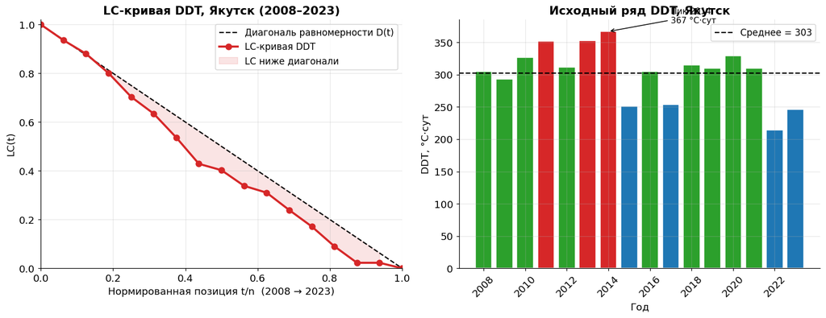

```python
# --- Демонстрация LC-кривой DDT Якутска ---
DDT = [305, 293, 327, 352, 312, 353, 367, 251, 305, 254, 315, 310, 329, 310, 214, 246]
n = len(DDT)
def min_max(x):
    a, b = min(x), max(x)
    return [(v - a) / (b - a) for v in x]
def lc(v):
    s = sum(v); n = len(v)
    return [sum(v[t:]) / s for t in range(n + 1)]
xs = [t/n for t in range(n+1)]
diag = [(n-t)/n for t in range(n+1)]
LC_DDT = lc(min_max(DDT))

fig, axes = plt.subplots(1, 2, figsize=(14, 5.5))
ax = axes[0]
ax.plot(xs, diag, '--', color='black', linewidth=1.5, label='Диагональ равномерности D(t)')
ax.plot(xs, LC_DDT, '-o', color='#d62728', linewidth=2.5, markersize=7, label='LC-кривая DDT')
ax.fill_between(xs, LC_DDT, diag, where=[a<b for a,b in zip(LC_DDT, diag)],
                color='#d62728', alpha=0.12, label='LC ниже диагонали')
ax.set_xlabel('Нормированная позиция t/n  (2008 → 2023)'); ax.set_ylabel('LC(t)')
ax.set_title('LC-кривая DDT, Якутск (2008–2023)', fontweight='bold')
ax.set_xlim(0,1); ax.set_ylim(0,1.02); ax.legend(fontsize=11)

ax = axes[1]
mean_ddt = sum(DDT)/len(DDT)
colors = ['#1f77b4' if v < mean_ddt-30 else ('#d62728' if v > mean_ddt+30 else '#2ca02c') for v in DDT]
ax.bar(years, DDT, color=colors, edgecolor='white')
ax.axhline(mean_ddt, color='black', linestyle='--', linewidth=1.5, label=f'Среднее = {mean_ddt:.0f}')
ax.set_xticks(years[::2]); ax.tick_params(axis='x', rotation=45)
ax.set_xlabel('Год'); ax.set_ylabel('DDT, °C·сут')
ax.set_title('Исходный ряд DDT, Якутск', fontweight='bold')
ax.legend(fontsize=11)
ax.annotate(f'Пик 2014:\n{max(DDT)} °C·сут',
            xy=(2014, max(DDT)), xytext=(2017, 380),
            arrowprops=dict(arrowstyle='->'), fontsize=10)
plt.tight_layout(); plt.show()
```

# 5. Интегральный индикатор PSRS — интерактивная модель

## Permafrost Settlement Risk Score

Безразмерная балльная шкала **0–10** для оценки риска просадки оснований капитальных сооружений, возведённых по **Принципу I** (СП 25.13330.2012 — сохранение мёрзлого состояния грунта).

## Формула

$$\text{PSRS} = \text{clip}\!\Big(5{,}0 + 1{,}6 \cdot (0{,}40 \cdot Z_{ALT} + 0{,}30 \cdot Z_{T320} + 0{,}20 \cdot Z_{H_{snow}} + 0{,}10 \cdot Z_{ROS}),\ 0,\ 10\Big)$$

где $Z_X = (X_t - \bar X)/\sigma_X$ — стандартизованное отклонение параметра $X$ от опорной нормы.

## Опорные нормы (Якутск, файл `data/permafrost_model/dss.py`)

| Параметр | $\bar X$ | $\sigma_X$ | Смысл |
| --- | --- | --- | --- |
| ALT (глубина протаивания, см) | 221,5 | 12,8 | Локальный антропогенно-тепловой сигнал |
| T320 (температура грунта на 3,2 м, °C) | −0,58 | 0,32 | Устойчивость зоны под фундаментами |
| Hsnow (макс. высота снега, см) | 35,4 | 8,6 | Снежно-отепляющий эффект |
| ROS (rain-on-snow, дней) | 1,6 | 1,1 | Уплотнение снега, ледяные корки |

## Шкала зон риска

**🟢 ЗЕЛЁНАЯ — PSRS < 4,0**  
*Плановый мониторинг 2 раза в год*

**🟡 ЖЁЛТАЯ — 4,0 ≤ PSRS < 7,0**  
*Усиленный мониторинг ежемесячно, активация СОУ*

**🔴 КРАСНАЯ — PSRS ≥ 7,0**  
*Режим ЧС, экстренная эвакуация, укрепление свай*

## 👉 Интерактивная модель ниже

**Передвигайте слайдеры — программа в реальном времени пересчитывает PSRS и подсвечивает зону риска.**

```python
# --- ИНТЕРАКТИВНАЯ МОДЕЛЬ PSRS (с использованием ipywidgets) ---

# Опорные нормы из data/permafrost_model/dss.py
STATS = {
    'alt':  {'mean': 221.5, 'std': 12.8},
    't320': {'mean': -0.58, 'std': 0.32},
    'snow': {'mean': 35.4,  'std': 8.6},
    'ros':  {'mean': 1.6,   'std': 1.1},
}
WEIGHTS = {'alt': 0.4, 't320': 0.3, 'snow': 0.2, 'ros': 0.1}

def calc_psrs(alt, t320, snow, ros):
    z = {
        'alt':  (alt  - STATS['alt']['mean'])  / STATS['alt']['std'],
        't320': (t320 - STATS['t320']['mean']) / STATS['t320']['std'],
        'snow': (snow - STATS['snow']['mean']) / STATS['snow']['std'],
        'ros':  (ros  - STATS['ros']['mean'])  / STATS['ros']['std'],
    }
    weighted_z = sum(WEIGHTS[k] * z[k] for k in z)
    score = 5.0 + 1.6 * weighted_z
    return max(0.0, min(score, 10.0)), z

def zone(score):
    if score < 4.0: return ('LOW',      '#82c997', '#E2EFDA', '🟢 ЗЕЛЁНАЯ — Низкий риск',
                            '<b>Действия:</b> плановый мониторинг 2 раза в год, обычный режим эксплуатации.')
    elif score < 7.0: return ('MODERATE', '#e0c24b', '#FFF2CC', '🟡 ЖЁЛТАЯ — Умеренный риск',
                              '<b>Действия:</b> ежемесячное обследование, активация СОУ, проверка готовности аварийных бригад.')
    else: return ('EXTREME',  '#d68080', '#FCE4D6', '🔴 КРАСНАЯ — Критический риск',
                  '<b>Действия:</b> режим ЧС, эвакуация из деформированных зданий, локальное отключение сетей, укрепление свай.')

def render(alt, t320, snow, ros):
    score, z = calc_psrs(alt, t320, snow, ros)
    lvl, ec, bg, title, action = zone(score)
    fig, axes = plt.subplots(1, 2, figsize=(14, 5))
    # --- LEFT: шкала с указателем ---
    ax = axes[0]
    ax.add_patch(Rectangle((0,0),  4, 1, color='#E2EFDA'))
    ax.add_patch(Rectangle((4,0),  3, 1, color='#FFF2CC'))
    ax.add_patch(Rectangle((7,0),  3, 1, color='#FCE4D6'))
    ax.axvline(score, color='black', linewidth=4)
    ax.text(score, 1.2, f'PSRS = {score:.2f}', ha='center', fontsize=24, fontweight='bold')
    ax.text(2.0, 0.5, 'LOW',      ha='center', va='center', fontsize=18, color='#256b30')
    ax.text(5.5, 0.5, 'MODERATE', ha='center', va='center', fontsize=18, color='#7a6a13')
    ax.text(8.5, 0.5, 'EXTREME',  ha='center', va='center', fontsize=18, color='#7a1d1d')
    ax.set_xlim(0, 10); ax.set_ylim(0, 2); ax.set_xticks(range(0, 11))
    ax.set_yticks([]); ax.set_title(title, fontsize=16, fontweight='bold')
    ax.tick_params(axis='x', labelsize=12)
    for spine in ax.spines.values(): spine.set_visible(False)
    # --- RIGHT: bar chart вкладов компонент ---
    ax = axes[1]
    comps = ['ALT', 'T320', 'Hsnow', 'ROS']
    z_vals = [z['alt'], z['t320'], z['snow'], z['ros']]
    contributions = [WEIGHTS[k] * z[k] * 1.6 for k in ['alt','t320','snow','ros']]
    colors = ['#d62728' if c > 0 else '#1f77b4' for c in contributions]
    ax.barh(comps, contributions, color=colors, edgecolor='black')
    for i, (c, zv) in enumerate(zip(contributions, z_vals)):
        ax.text(c + (0.03 if c >= 0 else -0.03), i, f'  Z={zv:+.2f}  ({c:+.2f} балла)',
                va='center', ha='left' if c>=0 else 'right', fontsize=11)
    ax.axvline(0, color='black', linewidth=0.8)
    ax.set_title('Вклад каждой компоненты в итоговый PSRS\n(красный — повышает риск, синий — понижает)',
                 fontweight='bold')
    ax.set_xlabel('Вклад в баллы PSRS')
    plt.tight_layout(); plt.show()
    display(HTML(f"<div style='padding:14px; background:{bg}; border:2px solid {ec}; border-radius:8px; font-size:15px;'>{action}</div>"))

if INTERACTIVE:
    interact = widgets.interactive(
        render,
        alt =widgets.FloatSlider(value=221.5, min=180, max=260, step=1.0, description='ALT, см:'),
        t320=widgets.FloatSlider(value=-0.58, min=-1.5, max=0.5, step=0.01, description='T320, °C:'),
        snow=widgets.FloatSlider(value=35.4,  min=15,  max=70,   step=1.0, description='Hsnow, см:'),
        ros =widgets.IntSlider  (value=2,     min=0,   max=10,   step=1,   description='ROS, дней:'),
    )
    display(interact)
else:
    # Без widgets — статичный пример для года 2023
    render(238, 0.15, 61, 5)
    print('Запустите с ipywidgets для интерактива.')
```

После каждого изменения видно, **какая именно компонента двигает индекс**.

# 6. Эмпирическая верификация PSRS

## Вопрос комиссии: «Откуда веса 0,4 / 0,3 / 0,2 / 0,1?»

## Ответ

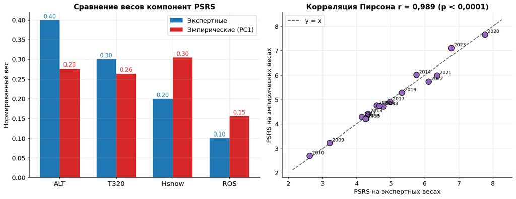

```python
# --- Сравнение экспертных и эмпирических весов + согласованность PSRS ---
fig, axes = plt.subplots(1, 2, figsize=(14, 5.5))
# Слева: веса
labels = ['ALT', 'T320', 'Hsnow', 'ROS']
expert = [0.40, 0.30, 0.20, 0.10]
empirical = [0.276, 0.264, 0.304, 0.155]
x = np.arange(len(labels)); w = 0.35
ax = axes[0]
ax.bar(x - w/2, expert, w, label='Экспертные', color='#1f77b4')
ax.bar(x + w/2, empirical, w, label='Эмпирические (PC1)', color='#d62728')
ax.set_xticks(x); ax.set_xticklabels(labels, fontsize=13)
ax.set_ylabel('Нормированный вес')
ax.set_title('Сравнение весов компонент PSRS', fontweight='bold')
for i in range(4):
    ax.text(i - w/2, expert[i]+0.005, f'{expert[i]:.2f}', ha='center', fontsize=11, color='#1f77b4')
    ax.text(i + w/2, empirical[i]+0.005, f'{empirical[i]:.2f}', ha='center', fontsize=11, color='#d62728')
ax.legend(fontsize=12)
# Справа: согласованность
ax = axes[1]
ax.scatter(df_psrs['PSRS_expert'], df_psrs['PSRS_empirical'], s=120, c='#9467bd', edgecolor='black', zorder=3)
mn, mx = df_psrs['PSRS_expert'].min()-0.5, df_psrs['PSRS_expert'].max()+0.5
ax.plot([mn, mx], [mn, mx], 'k--', alpha=0.6, label='y = x')
for _, r in df_psrs.iterrows():
    ax.annotate(int(r['year']), (r['PSRS_expert'], r['PSRS_empirical']),
                fontsize=9, xytext=(5,3), textcoords='offset points')
ax.set_xlabel('PSRS на экспертных весах'); ax.set_ylabel('PSRS на эмпирических весах')
ax.set_title('Корреляция Пирсона r = 0,989 (p < 0,0001)', fontweight='bold')
ax.legend(fontsize=12)
plt.tight_layout(); plt.show()
```

## Дополнительная проверка: связь PSRS с двумя целевыми переменными

| Целевая | $R^2$ | Значимые корреляции |
| --- | --- | --- |
| Число гидрологических ЧС | 0,043 | **нет** (все p > 0,6) |
| Число климатических экстремумов | 0,550 | Hsnow (p=0,004 **), T320 (p=0,012 *), ALT (p=0,037 *) |

**Эмпирически подтверждено:** PSRS — индикатор геокриологической напряжённости, **не** гидрологической. Это совпадает с методологическим разделением задач в работе (раздел 2.7).

# 7. Регламент действий РСЧС и кейс Норильск-2020

## Регламент по зонам PSRS — выдержка из реализованного DSS

| Зона | Управленческий режим | Ключевые действия |
| --- | --- | --- |
| 🟢 LOW | Штатный | Плановый мониторинг 2 раза/год; стандартная эксплуатация подполий |
| 🟡 MODERATE | Повышенная готовность | Ежемесячное обследование фундаментов; активация СОУ; проверка аварийных бригад |
| 🔴 EXTREME | Чрезвычайный | Введение режима ЧС; экстренная эвакуация; локальное отключение газа и ЛЭП; укрепление свай |

Полный список рекомендаций реализован в `data/permafrost_model/dss.py` (метод `evaluate_year`).

## Прецедент Норильск-2020

- **29 мая 2020 г.**: разрушение резервуара хранения дизельного топлива на ТЭЦ-3 АО «НТЭК».
- **Объём разлива:** около 21 тыс. тонн.
- **Причина (заключение Ростехнадзора):** просадка свайного основания вследствие оттаивания мерзлоты в зоне фундамента.
- **Уровень ЧС:** федеральный.

**Учебный вывод для МЧС.** Если бы по площадке велся ежегодный пересчёт PSRS, последовательные значения 7,5–9,0 за несколько сезонов перед аварией дали бы основание для перехода на чрезвычайный режим **задолго** до отказа основания.

# 8. Заключение и научная новизна

## Что сделано

1. Сформирована верифицированная информационная база по четырём опорным метеостанциям и пяти гидропостам р. Лены за 2008–2023 гг.
2. Изложен математический аппарат метода LC-кривых (Алескеров и др., 2025) и впервые **адаптирован для геокриологии и анализа гидрологических рисков**.
3. Построен интегральный индикатор **PSRS** — взвешенная свёртка четырёх компонент в шкалу 0–10 баллов с тремя зонами регламента действий.
4. Реализован программный модуль СППР `DecisionSupportSystem` (Python + JavaScript) с автоматической выдачей рекомендаций оперативному штабу.
5. Подготовлено учебно-методическое пособие для курсантов МЧС России.

## Научная новизна

- **Перенос метода LC-кривых из области экономики в область геокриологии и оперативного управления.**
- **Интегральный индекс PSRS** для оценки риска просадки оснований капитальных сооружений в криолитозоне — впервые сформулирован и реализован.
- **Сценарная матрица реагирования** РСЧС, сопряжённая с балльной шкалой индикатора, — практический управленческий инструмент.

## Практический выход

- Готовый к запуску модуль СППР.
- Учебно-методическое пособие для оперативного состава.
- Открытый репозиторий с воспроизводимыми расчётами.

## Ограничения, признанные в работе

- Прямая валидация PSRS на инженерных инцидентах в открытом доступе невозможна — используется суррогатная валидация (тренд ALT R42, температура грунта на 3,2 м, тренд DDT в LC-пространстве с лагом 2–3 года).
- Веса 0,4 / 0,3 / 0,2 / 0,1 — экспертные; эмпирическая верификация (PCA) показала их робастность.

## Готовые материалы

| Документ | Файл |
| --- | --- |
| Глава 2 ВКР | `Diploma/Chapter_2_imago_v10.docx` |
| Методичка PSRS для МЧС | `Diploma/Методичка_PSRS_для_МЧС.docx` |
| Отчёт по верификации PSRS | `Diploma/Отчёт_верификация_PSRS.docx` |
| Программный модуль СППР | `data/permafrost_model/dss.py` |
| Веб-СППР | `web_dss/src/mathCore.js` |
| Демо-ноутбук защиты | `Diploma/Demo_Defense.ipynb` (этот файл) |

## Благодарю за внимание

Готова ответить на вопросы комиссии